# Times Series Analysis

Pablo E. Gutiérrez-Fonseca

12 February, 2023

#### **Step 1**

Load libraries.

```r
libraries <- c('Kendall', 'trend', 'changepoint')
lapply(libraries, require, character.only = TRUE)
```

```
## [[1]]
## [1] TRUE
##
## [[2]]
## [1] TRUE
##
## [[3]]
## [1] TRUE
```

#### **Step 2**

```r
rain <- read.csv("D:/OneDrive - University of Vermont/Curriculum/19_ Personal webpage/TropicalFreshwaterEcology/_pages/Lectures/data/StreamEcology_TS_precipitation.csv")
rainEVFS <- rain[,3] # Select colunm 3.
```

#### **Step 3**

```r
rain.ts <- ts(rainEVFS, # Convert "Precipitation" to a time series object.
                    frequency=12, start=c(1975,1), end=c(2016,12))
head(rain.ts, n=24)
```

```
##  [1] 301.6  76.1  63.8 189.4 188.9  75.4 201.5 293.9 620.7 431.9 367.0 589.9
## [13] 158.3 272.8 192.2 134.0 215.9 394.4 179.0 278.7 444.2 368.6 190.1 205.4
```

#### **Step 4**

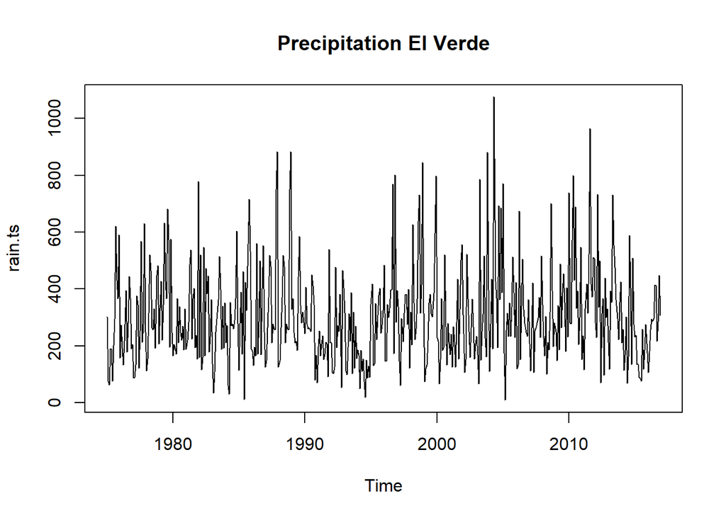

```r
plot(rain.ts, main="Precipitation El Verde")
```

## Mann-Kendall Trend Test

#### **Step 5**

We can use the Mann-Kendall Trend Test to see if there is a pattern in the data.

```r
MannKendall(rain.ts)
```

```
## tau = 0.0301, 2-sided pvalue =0.31262
```

```r
# tau is a measure of the strength of the trend
# p-value for trend is also shown
```

The test statistic is 0.0301, and the two-sided p-value associated with it is not less than 0.05. We cannot reject the null hypothesis of the test and conclude that no trend exists in the data because the p-value is greater than 0.05.

#### **Step 6**

Plot and trend Now we can add a smooth line to visualize the trend.

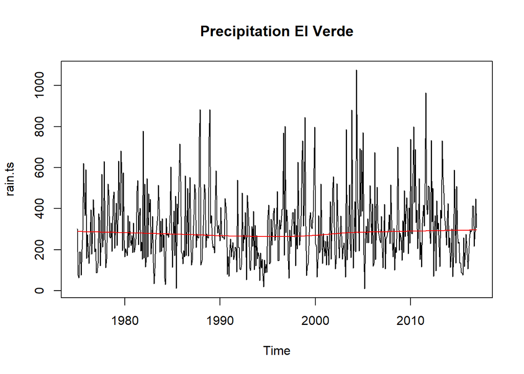

```r
plot(rain.ts, main="Precipitation El Verde")
lines(lowess(time(rain.ts), rain.ts), col='red')
```

## Sen’s slope

#### **Step 7**

The sens.slope function in the trend package is used with a time series object.  
The sea.sens.slope function performs the test while taking into account the seasonality of the data.

```r
sens.slope(rain.ts)
```

```
##
##  Sen's slope
##
## data:  rain.ts
## z = 1.0097, n = 504, p-value = 0.3126
## alternative hypothesis: true z is not equal to 0
## 95 percent confidence interval:
##  -0.04469697  0.13496333
## sample estimates:
## Sen's slope
##  0.04663441
```

## Pettitt’s test for change in value

#### **Step 8**

```r
pettitt.test(rain.ts)
```

```
##
##  Pettitt's test for single change-point detection
##
## data:  rain.ts
## U* = 7802, p-value = 0.116
## alternative hypothesis: two.sided
## sample estimates:
## probable change point at time K
##                             244
```

```r
rain[244,]
```

```
##     year month Rainfall
## 244 1995   abr   136.87
```

## Multiple changes points

#### **Step 9**

The next few commands will be used to find a potential change point in the mean.

```r
mvalueS = cpt.mean(rain.ts, method="BinSeg", Q=5) # BinSeg Binary Segmentation
cpts(mvalueS)
```

```
## [1]   7 189 255 420 468
```

```r
rain[c(7,189,255,420,468),]
```

```
##     year month Rainfall
## 7   1975   jul   201.50
## 189 1990   sep   346.70
## 255 1996   mar   146.30
## 420 2009   dic   232.51
## 468 2013   dic   425.72
```

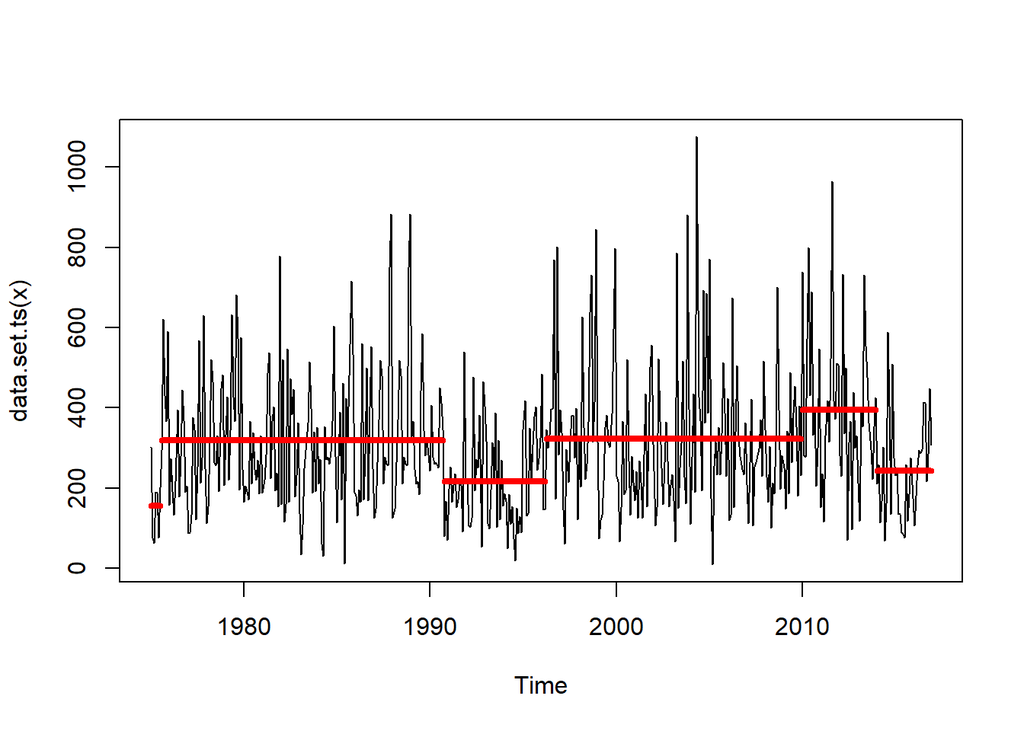

```r
plot(mvalueS, cpt.width = 4)
```